# Background and Context

```
The quantile values for 25, 50 and 75 percentiles respectively for  CustomerID  are given by:
0.25    201221.75
0.50    202443.50
0.75    203665.25
Name: CustomerID, dtype: float64
Resulting in an IQR of: 2443.5
Leading to the respective lower and upper outer fences of 193891.25 and 210995.75
```

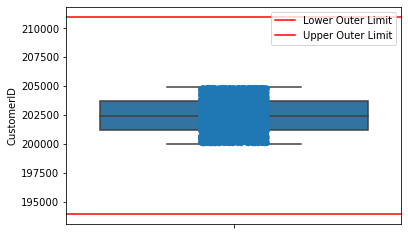

```
The quantile values for 25, 50 and 75 percentiles respectively for  ProdTaken  are given by:
0.25    0.0
0.50    0.0
0.75    0.0
Name: ProdTaken, dtype: float64
Resulting in an IQR of: 0.0
Leading to the respective lower and upper outer fences of 0.0 and 0.0
```

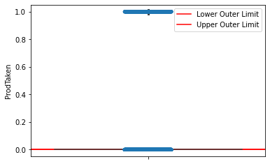

```
The quantile values for 25, 50 and 75 percentiles respectively for  Age  are given by:
0.25    31.0
0.50    36.0
0.75    43.0
Name: Age, dtype: float64
Resulting in an IQR of: 12.0
Leading to the respective lower and upper outer fences of -5.0 and 79.0
```

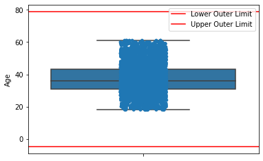

```
The quantile values for 25, 50 and 75 percentiles respectively for  CityTier  are given by:
0.25    1.0
0.50    1.0
0.75    3.0
Name: CityTier, dtype: float64
Resulting in an IQR of: 2.0
Leading to the respective lower and upper outer fences of -5.0 and 9.0
```

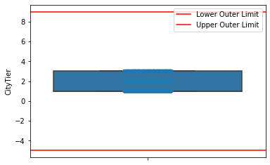

```
The quantile values for 25, 50 and 75 percentiles respectively for  DurationOfPitch  are given by:
0.25     9.0
0.50    13.0
0.75    19.0
Name: DurationOfPitch, dtype: float64
Resulting in an IQR of: 10.0
Leading to the respective lower and upper outer fences of -21.0 and 49.0
```

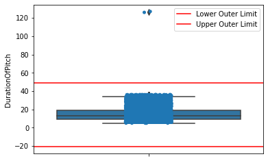

```
The quantile values for 25, 50 and 75 percentiles respectively for  NumberOfPersonVisiting  are given by:
0.25    2.0
0.50    3.0
0.75    3.0
Name: NumberOfPersonVisiting, dtype: float64
Resulting in an IQR of: 1.0
Leading to the respective lower and upper outer fences of -1.0 and 6.0
```

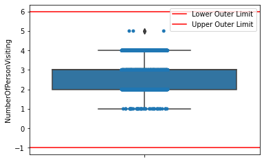

```
The quantile values for 25, 50 and 75 percentiles respectively for  NumberOfFollowups  are given by:
0.25    3.0
0.50    4.0
0.75    4.0
Name: NumberOfFollowups, dtype: float64
Resulting in an IQR of: 1.0
Leading to the respective lower and upper outer fences of 0.0 and 7.0
```

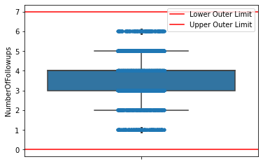

```
The quantile values for 25, 50 and 75 percentiles respectively for  PreferredPropertyStar  are given by:
0.25    3.0
0.50    3.0
0.75    4.0
Name: PreferredPropertyStar, dtype: float64
Resulting in an IQR of: 1.0
Leading to the respective lower and upper outer fences of 0.0 and 7.0
```

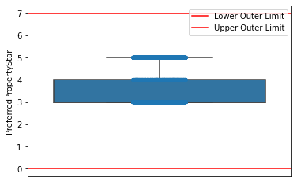

```
The quantile values for 25, 50 and 75 percentiles respectively for  NumberOfTrips  are given by:
0.25    2.0
0.50    3.0
0.75    4.0
Name: NumberOfTrips, dtype: float64
Resulting in an IQR of: 2.0
Leading to the respective lower and upper outer fences of -4.0 and 10.0
```

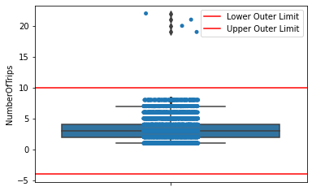

```
The quantile values for 25, 50 and 75 percentiles respectively for  Passport  are given by:
0.25    0.0
0.50    0.0
0.75    1.0
Name: Passport, dtype: float64
Resulting in an IQR of: 1.0
Leading to the respective lower and upper outer fences of -3.0 and 4.0
```

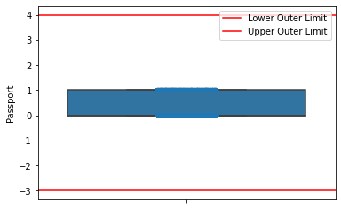

```
The quantile values for 25, 50 and 75 percentiles respectively for  PitchSatisfactionScore  are given by:
0.25    2.0
0.50    3.0
0.75    4.0
Name: PitchSatisfactionScore, dtype: float64
Resulting in an IQR of: 2.0
Leading to the respective lower and upper outer fences of -4.0 and 10.0
```

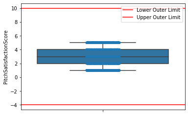

```
The quantile values for 25, 50 and 75 percentiles respectively for  OwnCar  are given by:
0.25    0.0
0.50    1.0
0.75    1.0
Name: OwnCar, dtype: float64
Resulting in an IQR of: 1.0
Leading to the respective lower and upper outer fences of -3.0 and 4.0
```

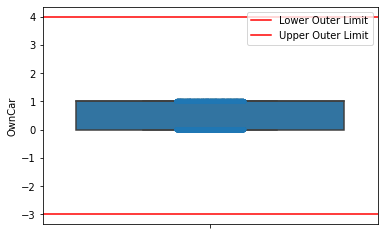

```
The quantile values for 25, 50 and 75 percentiles respectively for  NumberOfChildrenVisiting  are given by:
0.25    1.0
0.50    1.0
0.75    2.0
Name: NumberOfChildrenVisiting, dtype: float64
Resulting in an IQR of: 1.0
Leading to the respective lower and upper outer fences of -2.0 and 5.0
```

[2 more figures not shown]

```python
numerics = ['int64', 'float64']

for n in tour_df_fix.select_dtypes(include=numerics).columns:
    quantile_data = tour_df_fix[n].quantile([0.25,0.5,0.75])
    IQR = max(quantile_data.values)-min(quantile_data.values)
    low_out = min(quantile_data.values)-3*IQR
    upper_out = max(quantile_data.values)+3*IQR
    print('The quantile values for 25, 50 and 75 percentiles respectively for ',n,' are given by:')
    print(quantile_data)
    print('Resulting in an IQR of: '+str(IQR))
    print('Leading to the respective lower and upper outer fences of '+str(low_out)+' and '+str(upper_out))
    sns.boxplot(y = tour_df_fix[n])
    sns.stripplot(y = tour_df_fix[n])
    plt.axhline(y = low_out, color = 'r', linestyle = '-',label='Lower Outer Limit')
    plt.axhline(y = upper_out, color = 'r', linestyle = '-',label='Upper Outer Limit')
    plt.legend(bbox_to_anchor = (1.0, 1),loc = 'upper right')
    plt.show()
```

Observing the distributions for the variables that contain values outside the IQR ranges, we can conlude that these are proper outliers that could bias our models. Below we remove and confirm:

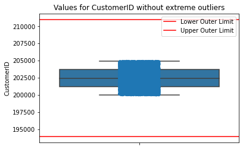

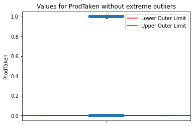

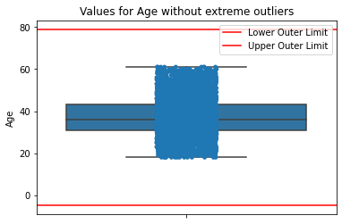

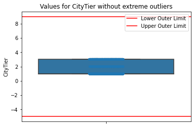

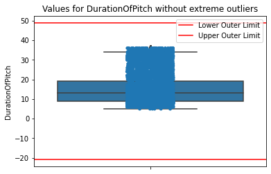

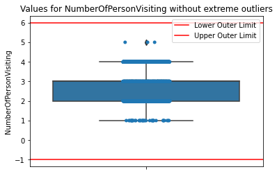

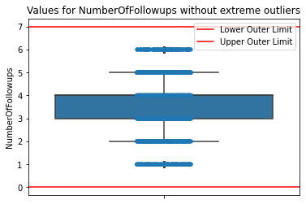

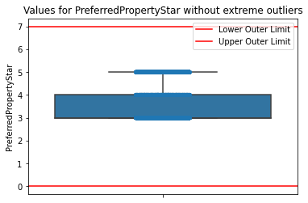

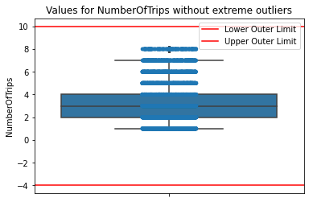

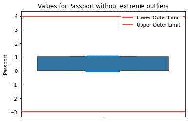

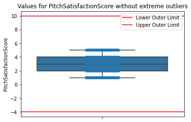

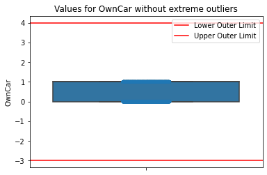

[2 more figures not shown]

```python
for n in tour_df_fix.select_dtypes(include=numerics).columns:
    quantile_data = tour_df_fix[n].quantile([0.25,0.5,0.75])
    IQR = max(quantile_data.values)-min(quantile_data.values)
    low_out = min(quantile_data.values)-3*IQR
    upper_out = max(quantile_data.values)+3*IQR

    if len(tour_df_fix[n].loc[(tour_df_fix[n]>upper_out)|(tour_df_fix[n]<low_out)])<100:
        tour_df_fix[n].loc[(tour_df_fix[n]>upper_out)|(tour_df_fix[n]<low_out)] = np.median(tour_df_fix[n].values)

    sns.boxplot(y = tour_df_fix[n])
    sns.stripplot(y = tour_df_fix[n])
    plt.axhline(y = low_out, color = 'r', linestyle = '-',label='Lower Outer Limit')
    plt.axhline(y = upper_out, color = 'r', linestyle = '-',label='Upper Outer Limit')
    plt.legend(bbox_to_anchor = (1.0, 1),loc = 'upper right')
    plt.title('Values for '+n+' without extreme outliers')
    plt.show()
```

```python
tour_df_fix.info()
```

```
<class 'pandas.core.frame.DataFrame'>
Int64Index: 4888 entries, 0 to 4887
Data columns (total 20 columns):
 #   Column                    Non-Null Count  Dtype
---  ------                    --------------  -----
 0   CustomerID                4888 non-null   float64
 1   ProdTaken                 4888 non-null   float64
 2   Age                       4888 non-null   float64
 3   TypeofContact             4888 non-null   object
 4   CityTier                  4888 non-null   float64
 5   DurationOfPitch           4888 non-null   float64
 6   Occupation                4888 non-null   object
 7   Gender                    4888 non-null   object
 8   NumberOfPersonVisiting    4888 non-null   float64
 9   NumberOfFollowups         4888 non-null   float64
 10  ProductPitched            4888 non-null   object
 11  PreferredPropertyStar     4888 non-null   float64
 12  MaritalStatus             4888 non-null   object
 13  NumberOfTrips             4888 non-null   float64
 14  Passport                  4888 non-null   float64
 15  PitchSatisfactionScore    4888 non-null   float64
 16  OwnCar                    4888 non-null   float64
 17  NumberOfChildrenVisiting  4888 non-null   float64
 18  Designation               4888 non-null   object
 19  MonthlyIncome             4888 non-null   float64
dtypes: float64(14), object(6)
memory usage: 801.9+ KB
```

### Customer Profile

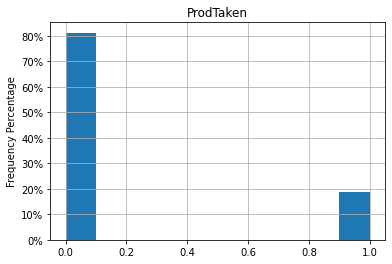

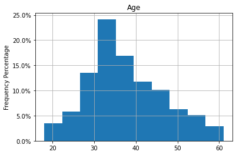

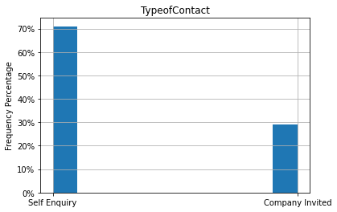

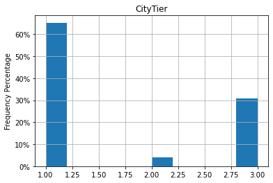

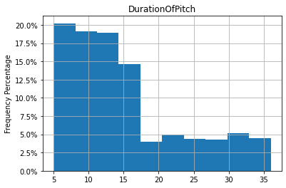

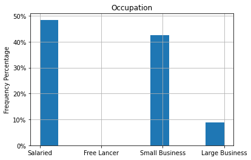

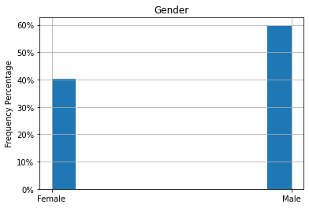

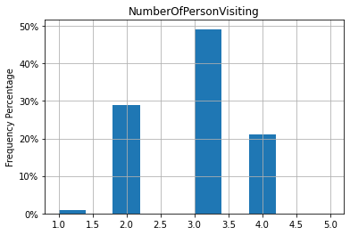

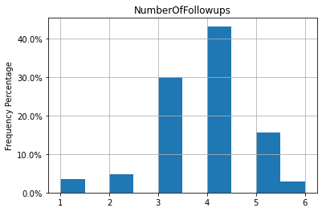

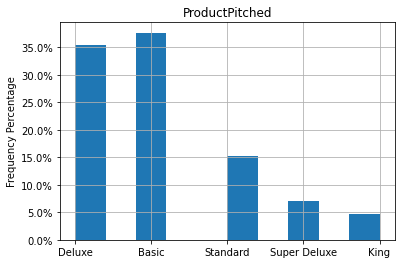

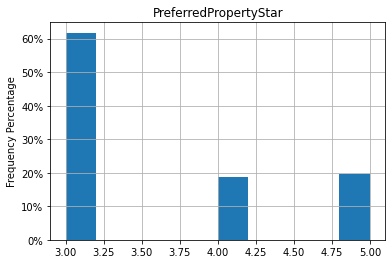

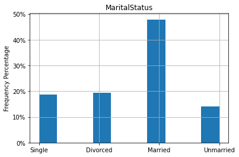

[7 more figures not shown]

```python
for x in tour_df_fix.drop(columns='CustomerID').columns:
    tour_df_fix[str(x)].hist(weights=np.ones(len(tour_df_fix[str(x)])) / len(tour_df_fix[str(x)]))
    plt.title(x)
    plt.gca().yaxis.set_major_formatter(PercentFormatter(1))
    plt.ylabel('Frequency Percentage')
    plt.show()
```

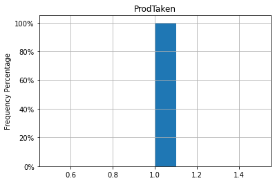

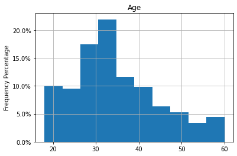

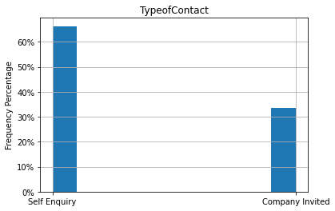

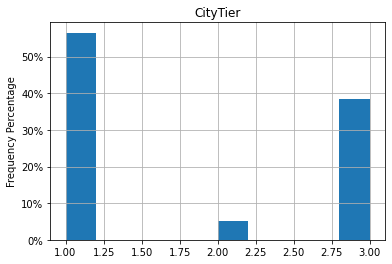

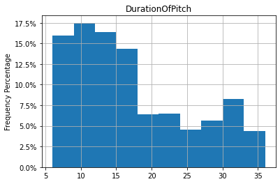

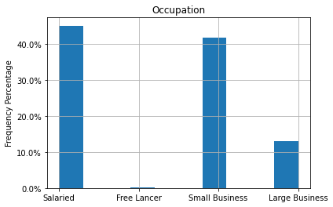

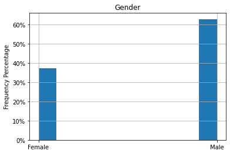

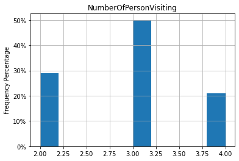

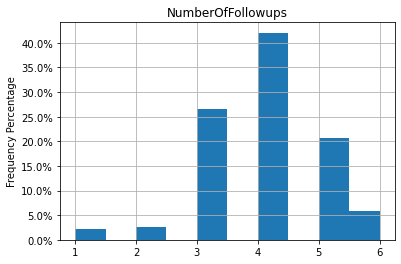

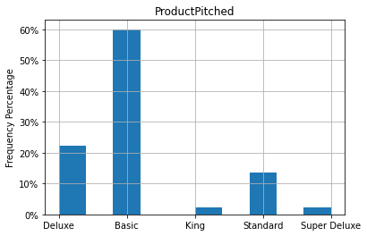

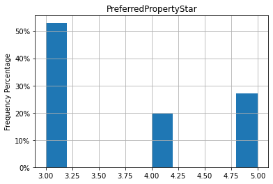

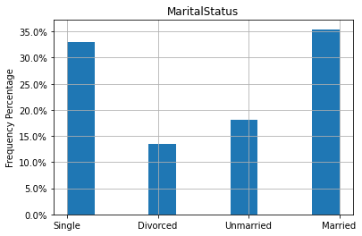

[7 more figures not shown]

```python
likely_customers = tour_df_fix.loc[tour_df_fix['ProdTaken']==1]

for x in likely_customers.drop(columns='CustomerID').columns:
    likely_customers[str(x)].hist(weights=np.ones(len(likely_customers[str(x)])) / len(likely_customers[str(x)]))
    plt.title(x)
    plt.gca().yaxis.set_major_formatter(PercentFormatter(1))
    plt.ylabel('Frequency Percentage')
    plt.show()
```

There are small variations between these two types of consumers. It might be easier to assess these differences through side-by-side violinplots.

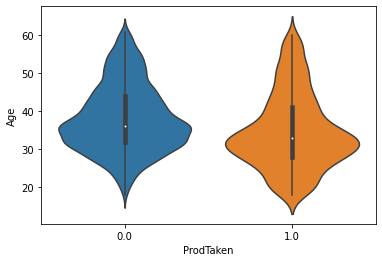

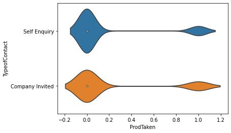

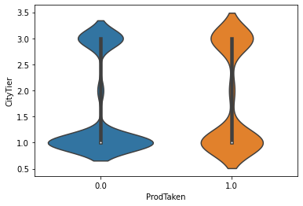

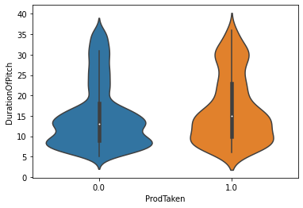

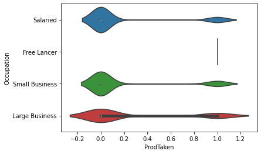

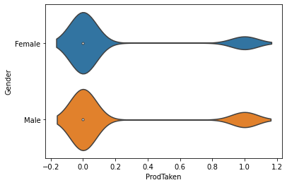

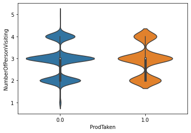

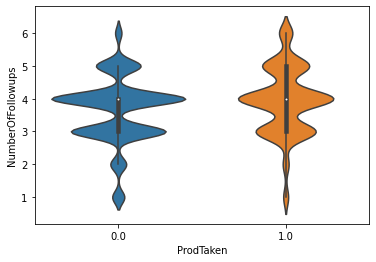

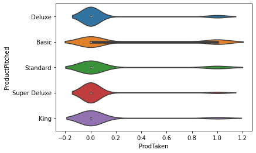

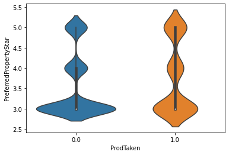

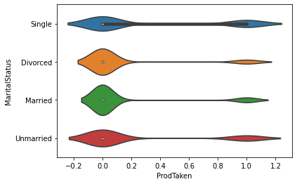

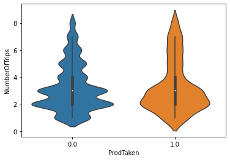

[6 more figures not shown]

```python
for t in tour_df_fix.drop(columns=['CustomerID','ProdTaken']).columns:
    sns.violinplot(data=tour_df_fix,x='ProdTaken',y=t)
    plt.show()
```

When plotting the distribution between the customers that took the offer versus those that didn't we can see that:

- They tend to be self motivated to find the offers
- Live mostly in the Tier 1 and 3 cities
- Are primarily middle class, being either salaried or small business owners, making on average 20k-25k a year
  - Free lancers seem to be highly likely to seek and accept these offers
- They seem to be 1.5X more likely to be male
- Are less likely to be divorced or unmarried. Either bachelor/bachelorettes or married individuals seem more interested in accepting such offers
- Average around 2 trips per year

### Engineering data for modeling

```python
cat_cols = tour_df_fix.select_dtypes(include='object').columns

for feature in cat_cols:
    print(tour_df_fix[feature].value_counts())

    unique_vals = tour_df_fix[feature].unique()

    for ind,val in enumerate(unique_vals):
        tour_df_fix[feature].loc[tour_df_fix[feature]==val] = ind+1


for feature in tour_df_fix.columns: # Loop through all columns in the dataframe
    if tour_df_fix[feature].dtype == 'object': # Only apply for columns with categorical strings
        tour_df_fix[feature] = pd.Categorical(tour_df_fix[feature])# Replace strings with an integer

tour_df_fix.sample(15)
```

```
Self Enquiry       3469
Company Invited    1419
Name: TypeofContact, dtype: int64
Salaried          2368
Small Business    2084
Large Business     434
Free Lancer          2
Name: Occupation, dtype: int64
Male      2916
Female    1972
Name: Gender, dtype: int64
Basic           1842
Deluxe          1732
Standard         742
Super Deluxe     342
King             230
Name: ProductPitched, dtype: int64
Married      2340
Divorced      950
Single        916
Unmarried     682
Name: MaritalStatus, dtype: int64
Executive         1842
Manager           1732
Senior Manager     742
AVP                342
VP                 230
Name: Designation, dtype: int64
```

|  | CustomerID | ProdTaken | Age | TypeofContact | CityTier | DurationOfPitch | Occupation | Gender | NumberOfPersonVisiting | NumberOfFollowups | ProductPitched | PreferredPropertyStar | MaritalStatus | NumberOfTrips | Passport | PitchSatisfactionScore | OwnCar | NumberOfChildrenVisiting | Designation | MonthlyIncome |
| --- | --- | --- | --- | --- | --- | --- | --- | --- | --- | --- | --- | --- | --- | --- | --- | --- | --- | --- | --- | --- |
| 2255 | 202255.0 | 0.0 | 40.0 | 1 | 1.0 | 26.0 | 4 | 2 | 3.0 | 3.0 | 3 | 3.0 | 3 | 5.0 | 0.0 | 3.0 | 1.0 | 1.0 | 3 | 25322.0 |
| 3919 | 203919.0 | 0.0 | 33.0 | 2 | 1.0 | 9.0 | 1 | 2 | 4.0 | 4.0 | 2 | 3.0 | 4 | 2.0 | 0.0 | 3.0 | 1.0 | 2.0 | 2 | 21746.0 |
| 394 | 200394.0 | 0.0 | 31.0 | 1 | 1.0 | 13.0 | 3 | 1 | 2.0 | 3.0 | 1 | 5.0 | 2 | 2.0 | 0.0 | 2.0 | 1.0 | 0.0 | 1 | 22347.0 |
| 1173 | 201173.0 | 0.0 | 36.0 | 1 | 1.0 | 11.0 | 1 | 1 | 2.0 | 3.0 | 3 | 5.0 | 3 | 5.0 | 0.0 | 4.0 | 1.0 | 1.0 | 3 | 23008.0 |
| 3227 | 203227.0 | 0.0 | 42.0 | 1 | 1.0 | 14.0 | 4 | 1 | 3.0 | 2.0 | 2 | 3.0 | 2 | 3.0 | 0.0 | 3.0 | 1.0 | 2.0 | 2 | 22054.0 |
| 2991 | 202991.0 | 1.0 | 43.0 | 2 | 1.0 | 26.0 | 3 | 2 | 3.0 | 3.0 | 2 | 3.0 | 3 | 8.0 | 1.0 | 3.0 | 1.0 | 2.0 | 2 | 21437.0 |
| 3070 | 203070.0 | 0.0 | 33.0 | 1 | 1.0 | 15.0 | 3 | 1 | 4.0 | 2.0 | 1 | 3.0 | 2 | 7.0 | 0.0 | 3.0 | 1.0 | 3.0 | 1 | 23853.0 |
| 1787 | 201787.0 | 1.0 | 52.0 | 1 | 1.0 | 14.0 | 3 | 2 | 2.0 | 4.0 | 1 | 4.0 | 3 | 3.0 | 0.0 | 1.0 | 1.0 | 0.0 | 1 | 19941.0 |
| 1589 | 201589.0 | 0.0 | 43.0 | 2 | 3.0 | 32.0 | 1 | 2 | 3.0 | 3.0 | 4 | 3.0 | 3 | 2.0 | 1.0 | 1.0 | 1.0 | 0.0 | 4 | 31959.0 |
| 1316 | 201316.0 | 0.0 | 43.0 | 2 | 3.0 | 8.0 | 1 | 2 | 3.0 | 3.0 | 1 | 3.0 | 3 | 2.0 | 0.0 | 3.0 | 1.0 | 2.0 | 1 | 20675.0 |
| 1921 | 201921.0 | 0.0 | 42.0 | 1 | 1.0 | 30.0 | 3 | 2 | 2.0 | 3.0 | 3 | 5.0 | 3 | 2.0 | 1.0 | 1.0 | 1.0 | 0.0 | 3 | 22406.0 |
| 1864 | 201864.0 | 0.0 | 31.0 | 1 | 1.0 | 13.0 | 3 | 1 | 2.0 | 3.0 | 1 | 5.0 | 3 | 2.0 | 0.0 | 1.0 | 1.0 | 0.0 | 1 | 22347.0 |
| 3825 | 203825.0 | 0.0 | 29.0 | 2 | 1.0 | 23.0 | 3 | 2 | 3.0 | 4.0 | 2 | 3.0 | 1 | 3.0 | 0.0 | 3.0 | 0.0 | 1.0 | 2 | 20822.0 |
| 3806 | 203806.0 | 0.0 | 46.0 | 2 | 1.0 | 7.0 | 3 | 2 | 3.0 | 4.0 | 1 | 3.0 | 4 | 6.0 | 0.0 | 1.0 | 1.0 | 2.0 | 1 | 24077.0 |
| 817 | 200817.0 | 0.0 | 36.0 | 2 | 1.0 | 24.0 | 1 | 2 | 3.0 | 3.0 | 1 | 3.0 | 4 | 3.0 | 0.0 | 3.0 | 1.0 | 0.0 | 1 | 22779.0 |

We can turn catergoricals into dummy variables

```python
tour_df_fix=pd.get_dummies(tour_df_fix, columns=cat_cols)
tour_df_fix.info()
```

```
<class 'pandas.core.frame.DataFrame'>
Int64Index: 4888 entries, 0 to 4887
Data columns (total 36 columns):
 #   Column                    Non-Null Count  Dtype
---  ------                    --------------  -----
 0   CustomerID                4888 non-null   float64
 1   ProdTaken                 4888 non-null   float64
 2   Age                       4888 non-null   float64
 3   CityTier                  4888 non-null   float64
 4   DurationOfPitch           4888 non-null   float64
 5   NumberOfPersonVisiting    4888 non-null   float64
 6   NumberOfFollowups         4888 non-null   float64
 7   PreferredPropertyStar     4888 non-null   float64
 8   NumberOfTrips             4888 non-null   float64
 9   Passport                  4888 non-null   float64
```

[output cut: 28 more lines]

```python
X = tour_df_fix.drop(columns=['ProdTaken','CustomerID'])
Y = tour_df_fix.pop("ProdTaken")

X_train, X_test, y_train, y_test = train_test_split(X, Y, test_size=.30, random_state=1,stratify=Y)
```

```python
## Function to create confusion matrix
def make_confusion_matrix(model,y_actual,labels=[1, 0]):
    '''
    model : classifier to predict values of X
    y_actual : ground truth

    '''
    y_predict = model.predict(X_test)
    cm=metrics.confusion_matrix( y_actual, y_predict, labels=[0, 1])
    df_cm = pd.DataFrame(cm, index = [i for i in ["Actual - No","Actual - Yes"]],
                  columns = [i for i in ['Predicted - No','Predicted - Yes']])
    group_counts = ["{0:0.0f}".format(value) for value in
                cm.flatten()]
    group_percentages = ["{0:.2%}".format(value) for value in
                         cm.flatten()/np.sum(cm)]
    labels = [f"{v1}\n{v2}" for v1, v2 in
              zip(group_counts,group_percentages)]
    labels = np.asarray(labels).reshape(2,2)
    plt.figure(figsize = (10,7))
    sns.heatmap(df_cm, annot=labels,fmt='')
    plt.ylabel('True label')
    plt.xlabel('Predicted label')
```

```python
##  Function to calculate different metric scores of the model - Accuracy, Recall and Precision
def get_metrics_score(model,flag=True):
    '''
    model : classifier to predict values of X

    '''
    # defining an empty list to store train and test results
    score_list=[]

    pred_train = model.predict(X_train)
    pred_test = model.predict(X_test)

    train_acc = model.score(X_train,y_train)
    test_acc = model.score(X_test,y_test)

    train_recall = metrics.recall_score(y_train,pred_train)
    test_recall = metrics.recall_score(y_test,pred_test)

    train_precision = metrics.precision_score(y_train,pred_train)
    test_precision = metrics.precision_score(y_test,pred_test)

    train_f1 = metrics.f1_score(y_train,pred_train)
    test_f1 = metrics.f1_score(y_test,pred_test)

    score_list.extend((train_acc,test_acc,train_recall,test_recall,train_precision,test_precision,train_f1,test_f1))

    # If the flag is set to True then only the following print statements will be dispayed. The default value is set to True.
    if flag == True:
        print("Accuracy on training set : ",model.score(X_train,y_train))
        print("Accuracy on test set : ",model.score(X_test,y_test))
        print("Recall on training set : ",metrics.recall_score(y_train,pred_train))
        print("Recall on test set : ",metrics.recall_score(y_test,pred_test))
        print("Precision on training set : ",metrics.precision_score(y_train,pred_train))
        print("Precision on test set : ",metrics.precision_score(y_test,pred_test))
        print("F1 score on training set : ",metrics.f1_score(y_train,pred_train))
        print("F1 score on test set : ",metrics.f1_score(y_test,pred_test))

    return score_list # returning the list with train and test scores
```

### AdaBoost Classifier

```python
abc = AdaBoostClassifier(random_state=1)
abc.fit(X_train,y_train)
```

```
AdaBoostClassifier(random_state=1)
```

```
Accuracy on training set :  0.8433206664717918
Accuracy on test set :  0.8466257668711656
Recall on training set :  0.3105590062111801
Recall on test set :  0.3079710144927536
Precision on training set :  0.684931506849315
Precision on test set :  0.7142857142857143
F1 score on training set :  0.42735042735042733
F1 score on test set :  0.43037974683544306
```

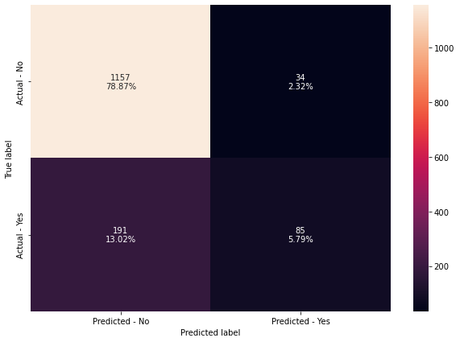

```python
abc_score=get_metrics_score(abc)

make_confusion_matrix(abc,y_test)
```

We can observe that while an AdaBoost classifier does not result in an overfit model, it performs very poorly, especially for the recall score. This would result in many likely clients not being targeted.

### Gradient Boosting Classifier

```python
gbc = GradientBoostingClassifier(random_state=1)
gbc.fit(X_train,y_train)
```

```
GradientBoostingClassifier(random_state=1)
```

```
Accuracy on training set :  0.8830751242326805
Accuracy on test set :  0.8643490115882754
Recall on training set :  0.4394409937888199
Recall on test set :  0.38768115942028986
Precision on training set :  0.8788819875776398
Precision on test set :  0.781021897810219
F1 score on training set :  0.5859213250517599
F1 score on test set :  0.5181598062953995
```

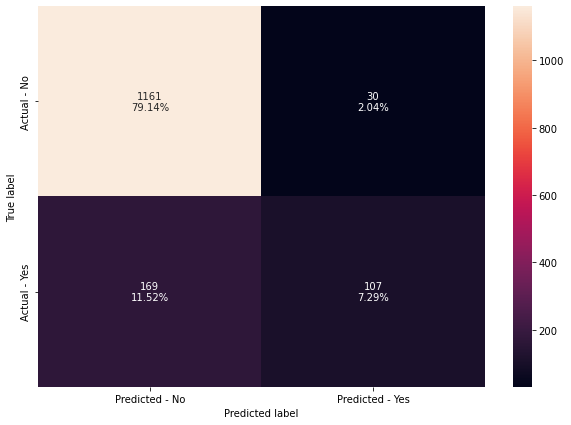

```python
gbc_score=get_metrics_score(gbc)
make_confusion_matrix(gbc,y_test)
```

Gradient Boosting shows an improvement in both Recall and Precision, however it still fails to capture many likely customers. Nevertheless, the higher precision indicates that at the very least this model would avoid investing targetting efforts on unlikely customers.

### Gradient Boosting Classifier Tuning

```python
gbc_tuned = GradientBoostingClassifier(init=AdaBoostClassifier(random_state=1),random_state=1)

# Grid of parameters to choose from
## add from article
parameters = {
    "n_estimators": [100,150,200,250],
    "subsample":[0.8,0.9,1],
    "max_features":[0.7,0.8,0.9,1]
}

# Type of scoring used to compare parameter combinations
acc_scorer = metrics.make_scorer(metrics.recall_score)

# Run the grid search
grid_obj = GridSearchCV(gbc_tuned, parameters, scoring=acc_scorer,cv=5)
grid_obj = grid_obj.fit(X_train, y_train)

# Set the clf to the best combination of parameters
gbc_tuned = grid_obj.best_estimator_

# Fit the best algorithm to the data.
gbc_tuned.fit(X_train, y_train)
```

```
GradientBoostingClassifier(init=AdaBoostClassifier(random_state=1),
                           max_features=0.7, n_estimators=250, random_state=1,
                           subsample=0.8)
```

```
Accuracy on training set :  0.9184448991522947
Accuracy on test set :  0.8773006134969326
Recall on training set :  0.6071428571428571
Recall on test set :  0.4746376811594203
Precision on training set :  0.9376498800959233
Precision on test set :  0.7891566265060241
F1 score on training set :  0.7370405278039586
F1 score on test set :  0.592760180995475
```

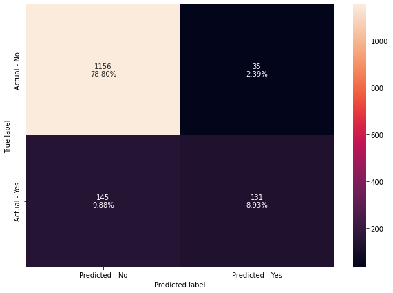

```python
gbc_tuned_score=get_metrics_score(gbc_tuned)

make_confusion_matrix(gbc_tuned,y_test)
```

Given that Gradient Boosting seemed promising, exploring a tuned version of GBC was worth exploring. While we observe an even further improvement in performance, we see signs of overfitting.

Using methods that mitigate overfitting are called for.